# Sparkify Project Workspace

This workspace contains a tiny subset (128MB) of the full dataset available (12GB). Feel free to use this workspace to build your project, or to explore a smaller subset with Spark before deploying your cluster on the cloud. Instructions for setting up your Spark cluster is included in the last lesson of the Extracurricular Spark Course content.

You can follow the steps below to guide your data analysis and model building portion of this project.

```python
# import libraries
from pyspark.sql import SparkSession
from pyspark.sql.functions import col, count, when
from pyspark.sql.functions import substring
from pyspark.sql.functions import desc, asc
from pyspark.sql.functions import split
from pyspark.sql.functions import sum as Fsum
from pyspark.sql.functions import min, max, avg

from pyspark.sql.window import Window

from pyspark.ml import Pipeline
from pyspark.ml.feature import StringIndexer
from pyspark.ml.feature import VectorAssembler
from pyspark.ml.feature import Normalizer
from pyspark.ml.feature import StandardScaler

from pyspark.ml.classification import RandomForestClassifier
from pyspark.ml.classification import LogisticRegression
from pyspark.ml.classification import GBTClassifier

from pyspark.ml.evaluation import BinaryClassificationEvaluator
from pyspark.ml.evaluation import MulticlassClassificationEvaluator

from pyspark.ml.tuning import CrossValidator, ParamGridBuilder

import pandas as pd
import numpy as np
import matplotlib.pyplot as plt
import seaborn as sns
```

```python
# create a Spark session
spark = SparkSession.builder.appName('sparkify').getOrCreate()

#the spark context
spark.sparkContext.getConf().getAll()
```

```
[('spark.driver.extraJavaOptions',
  '-Djava.net.preferIPv6Addresses=false -XX:+IgnoreUnrecognizedVMOptions --add-opens=java.base/java.lang=ALL-UNNAMED --add-opens=java.base/java.lang.invoke=ALL-UNNAMED --add-opens=java.base/java.lang.reflect=ALL-UNNAMED --add-opens=java.base/java.io=ALL-UNNAMED --add-opens=java.base/java.net=ALL-UNN…
 ('spark.app.submitTime', '1716394195038'),
 ('spark.driver.port', '52961'),
 ('spark.executor.id', 'driver'),
 ('spark.app.id', 'local-1716394196997'),
 ('spark.app.startTime', '1716394195233'),
 ('spark.app.name', 'sparkify'),
 ('spark.rdd.compress', 'True'),
 ('spark.executor.extraJavaOptions',
  '-Djava.net.preferIPv6Addresses=false -XX:+IgnoreUnrecognizedVMOptions --add-opens=java.base/java.lang=ALL-UNNAMED --add-opens=java.base/java.lang.invoke=ALL-UNNAMED --add-opens=java.base/java.lang.reflect=ALL-UNNAMED --add-opens=java.base/java.io=ALL-UNNAMED --add-opens=java.base/java.net=ALL-UNN…
 ('spark.serializer.objectStreamReset', '100'),
 ('spark.master', 'local[*]'),
 ('spark.submit.pyFiles', ''),
 ('spark.submit.deployMode', 'client'),
 ('spark.driver.host', 'Mikelenovo'),
 ('spark.ui.showConsoleProgress', 'true')]
```

# Load and Clean Dataset

In this workspace, the mini-dataset file is `mini_sparkify_event_data.json`. Load and clean the dataset, checking for invalid or missing data - for example, records without userids or sessionids.

```python
#read in the input file
df_spark = spark.read.json("mini_sparkify_event_data.json")
```

```python
#first 5 rows of the data/file
df_spark.show(5)
```

```
+----------------+---------+---------+------+-------------+--------+---------+-----+--------------------+------+--------+-------------+---------+--------------------+------+-------------+--------------------+------+
|          artist|     auth|firstName|gender|itemInSession|lastName|   length|level|            location|method|    page| registration|sessionId|                song|status|           ts|           userAgent|userId|
+----------------+---------+---------+------+-------------+--------+---------+-----+--------------------+------+--------+-------------+---------+--------------------+------+-------------+--------------------+------+
|  Martha Tilston|Logged In|    Colin|     M|           50| Freeman|277.89016| paid|     Bakersfield, CA|   PUT|NextSong|1538173362000|       29|           Rockpools|   200|1538352117000|Mozilla/5.0 (Wind...|    30|
|Five Iron Frenzy|Logged In|    Micah|     M|           79|    Long|236.09424| free|Boston-Cambridge-...|   PUT|NextSong|1538331630000|        8|              Canada|   200|1538352180000|"Mozilla/5.0 (Win...|     9|
|    Adam Lambert|Logged In|    Colin|     M|           51| Freeman| 282.8273| paid|     Bakersfield, CA|   PUT|NextSong|1538173362000|       29|   Time For Miracles|   200|1538352394000|Mozilla/5.0 (Wind...|    30|
|          Enigma|Logged In|    Micah|     M|           80|    Long|262.71302| free|Boston-Cambridge-...|   PUT|NextSong|1538331630000|        8|Knocking On Forbi...|   200|1538352416000|"Mozilla/5.0 (Win...|     9|
|       Daft Punk|Logged In|    Colin|     M|           52| Freeman|223.60771| paid|     Bakersfield, CA|   PUT|NextSong|1538173362000|       29|Harder Better Fas...|   200|1538352676000|Mozilla/5.0 (Wind...|    30|
+----------------+---------+---------+------+-------------+--------+---------+-----+--------------------+------+--------+-------------+---------+--------------------+------+-------------+--------------------+------+
only showing top 5 rows
```

```python
#first 5 rows of the data in a pandas dataframe view
df_spark.toPandas().head()
```

|  | artist | auth | firstName | gender | itemInSession | lastName | length | level | location | method | page | registration | sessionId | song | status | ts | userAgent | userId |
| --- | --- | --- | --- | --- | --- | --- | --- | --- | --- | --- | --- | --- | --- | --- | --- | --- | --- | --- |
| 0 | Martha Tilston | Logged In | Colin | M | 50 | Freeman | 277.89016 | paid | Bakersfield, CA | PUT | NextSong | 1.538173e+12 | 29 | Rockpools | 200 | 1538352117000 | Mozilla/5.0 (Windows NT 6.1; WOW64; rv:31.0) G... | 30 |
| 1 | Five Iron Frenzy | Logged In | Micah | M | 79 | Long | 236.09424 | free | Boston-Cambridge-Newton, MA-NH | PUT | NextSong | 1.538332e+12 | 8 | Canada | 200 | 1538352180000 | "Mozilla/5.0 (Windows NT 6.1; WOW64) AppleWebK... | 9 |
| 2 | Adam Lambert | Logged In | Colin | M | 51 | Freeman | 282.82730 | paid | Bakersfield, CA | PUT | NextSong | 1.538173e+12 | 29 | Time For Miracles | 200 | 1538352394000 | Mozilla/5.0 (Windows NT 6.1; WOW64; rv:31.0) G... | 30 |
| 3 | Enigma | Logged In | Micah | M | 80 | Long | 262.71302 | free | Boston-Cambridge-Newton, MA-NH | PUT | NextSong | 1.538332e+12 | 8 | Knocking On Forbidden Doors | 200 | 1538352416000 | "Mozilla/5.0 (Windows NT 6.1; WOW64) AppleWebK... | 9 |
| 4 | Daft Punk | Logged In | Colin | M | 52 | Freeman | 223.60771 | paid | Bakersfield, CA | PUT | NextSong | 1.538173e+12 | 29 | Harder Better Faster Stronger | 200 | 1538352676000 | Mozilla/5.0 (Windows NT 6.1; WOW64; rv:31.0) G... | 30 |

```python
#columns in the data with their data types
df_spark.printSchema()
```

```
root
 |-- artist: string (nullable = true)
 |-- auth: string (nullable = true)
 |-- firstName: string (nullable = true)
 |-- gender: string (nullable = true)
 |-- itemInSession: long (nullable = true)
 |-- lastName: string (nullable = true)
 |-- length: double (nullable = true)
 |-- level: string (nullable = true)
 |-- location: string (nullable = true)
 |-- method: string (nullable = true)
 |-- page: string (nullable = true)
 |-- registration: long (nullable = true)
 |-- sessionId: long (nullable = true)
 |-- song: string (nullable = true)
 |-- status: long (nullable = true)
 |-- ts: long (nullable = true)
 |-- userAgent: string (nullable = true)
 |-- userId: string (nullable = true)
```

```python
#row count
df_spark.count()
```

```
286500
```

```python
#number of the rows and columns
df_spark.count(), len(df_spark.columns)
```

```
(286500, 18)
```

```python
#Check for null/missing values values
df_spark.select([count(when(col(i).isNull(), i)).alias(i) for i in df_spark.columns]).show()
```

```
+------+----+---------+------+-------------+--------+------+-----+--------+------+----+------------+---------+-----+------+---+---------+------+
|artist|auth|firstName|gender|itemInSession|lastName|length|level|location|method|page|registration|sessionId| song|status| ts|userAgent|userId|
+------+----+---------+------+-------------+--------+------+-----+--------+------+----+------------+---------+-----+------+---+---------+------+
| 58392|   0|     8346|  8346|            0|    8346| 58392|    0|    8346|     0|   0|        8346|        0|58392|     0|  0|     8346|     0|
+------+----+---------+------+-------------+--------+------+-----+--------+------+----+------------+---------+-----+------+---+---------+------+
```

```python
#Drop rows that have firstName, gender, lastName, location, registration and userAgent as null
#these seems to be the users that did not register and hence cannot be said to be able to churn
#to do this we filter by firstName and gender and delete those records

df_spark_nonulls = df_spark.na.drop(subset=['firstName','gender'])
```

```python
#Recheck for null/missing values values
df_spark_nonulls.select([count(when(col(i).isNull(), i)).alias(i) for i in df_spark.columns]).show()
```

```
+------+----+---------+------+-------------+--------+------+-----+--------+------+----+------------+---------+-----+------+---+---------+------+
|artist|auth|firstName|gender|itemInSession|lastName|length|level|location|method|page|registration|sessionId| song|status| ts|userAgent|userId|
+------+----+---------+------+-------------+--------+------+-----+--------+------+----+------------+---------+-----+------+---+---------+------+
| 50046|   0|        0|     0|            0|       0| 50046|    0|       0|     0|   0|           0|        0|50046|     0|  0|        0|     0|
+------+----+---------+------+-------------+--------+------+-----+--------+------+----+------------+---------+-----+------+---+---------+------+
```

```python
#Check for duplicated rows
df_spark_nonulls.exceptAll(df_spark.dropDuplicates()).show()
```

```
+------+----+---------+------+-------------+--------+------+-----+--------+------+----+------------+---------+----+------+---+---------+------+
|artist|auth|firstName|gender|itemInSession|lastName|length|level|location|method|page|registration|sessionId|song|status| ts|userAgent|userId|
+------+----+---------+------+-------------+--------+------+-----+--------+------+----+------------+---------+----+------+---+---------+------+
+------+----+---------+------+-------------+--------+------+-----+--------+------+----+------------+---------+----+------+---+---------+------+
```

```python
#explore user ids
#there are records with no userids
df_spark_nonulls.select('userId').drop_duplicates().sort('userId').show()
```

```
+------+
|userId|
+------+
|    10|
|   100|
|100001|
|100002|
|100003|
|100004|
|100005|
|100006|
|100007|
|100008|
|100009|
|100010|
|100011|
|100012|
|100013|
|100014|
|100015|
|100016|
|100017|
|100018|
+------+
only showing top 20 rows
```

```python
#Check for duplicated artist and song
df_spark_nonulls.exceptAll(df_spark_nonulls.dropDuplicates(['artist','song'])).toPandas().sort_values(by='artist')
```

|  | artist | auth | firstName | gender | itemInSession | lastName | length | level | location | method | page | registration | sessionId | song | status | ts | userAgent | userId |
| --- | --- | --- | --- | --- | --- | --- | --- | --- | --- | --- | --- | --- | --- | --- | --- | --- | --- | --- |
| 210115 | !!! | Logged In | Lucero | F | 118 | Reed | 356.10077 | paid | Louisville/Jefferson County, KY-IN | PUT | NextSong | 1536642109000 | 1643 | Must Be The Moon | 200 | 1541513849000 | "Mozilla/5.0 (Windows NT 6.1; WOW64) AppleWebK... | 140 |
| 86710 | !!! | Logged In | Samuel | M | 396 | Wood | 356.10077 | paid | New York-Newark-Jersey City, NY-NJ-PA | PUT | NextSong | 1537865819000 | 1305 | Must Be The Moon | 200 | 1540661560000 | "Mozilla/5.0 (iPad; CPU OS 7_1_1 like Mac OS X... | 138 |
| 10660 | !!! | Logged In | Oliver | M | 364 | Gilbert | 313.10322 | paid | Philadelphia-Camden-Wilmington, PA-NJ-DE-MD | PUT | NextSong | 1535093367000 | 1616 | Yadnus | 200 | 1541562315000 | "Mozilla/5.0 (Macintosh; Intel Mac OS X 10_9_4... | 81 |
| 173713 | !!! | Logged In | Brayden | M | 279 | Thomas | 356.10077 | paid | Los Angeles-Long Beach-Anaheim, CA | PUT | NextSong | 1534133898000 | 2266 | Must Be The Moon | 200 | 1543261020000 | "Mozilla/5.0 (Macintosh; Intel Mac OS X 10_9_4... | 85 |
| 204327 | !!! | Logged In | Charlotte | F | 25 | Frazier | 294.94812 | free | Baltimore-Columbia-Towson, MD | PUT | NextSong | 1537537765000 | 31 | A New Name | 200 | 1539363278000 | "Mozilla/5.0 (Macintosh; Intel Mac OS X 10_9_4... | 200016 |
| ... | ... | ... | ... | ... | ... | ... | ... | ... | ... | ... | ... | ... | ... | ... | ... | ... | ... | ... |
| 212713 | None | Logged In | Chloe | F | 71 | Deleon | NaN | paid | Boston-Cambridge-Newton, MA-NH | PUT | Thumbs Up | 1530514394000 | 403 | None | 307 | 1542928092000 | "Mozilla/5.0 (Windows NT 6.1; WOW64) AppleWebK... | 300023 |
| 212714 | None | Logged In | Noah | M | 203 | Whitehead | NaN | paid | New Haven-Milford, CT | PUT | Thumbs Up | 1535361448000 | 410 | None | 307 | 1543096971000 | "Mozilla/5.0 (Macintosh; Intel Mac OS X 10_7_5... | 300006 |
| 212716 | None | Logged In | Carter | M | 32 | Tanner | NaN | paid | Miami-Fort Lauderdale-West Palm Beach, FL | PUT | Thumbs Up | 1530306321000 | 443 | None | 307 | 1543213699000 | "Mozilla/5.0 (Windows NT 5.1) AppleWebKit/537.... | 300012 |
| 212718 | None | Logged In | Emilia | F | 1 | House | NaN | paid | New York-Newark-Jersey City, NY-NJ-PA | PUT | Logout | 1538336771000 | 463 | None | 307 | 1543252271000 | Mozilla/5.0 (compatible; MSIE 9.0; Windows NT ... | 300011 |
| 212727 | None | Logged In | Joshua | M | 181 | Warner | NaN | paid | San Jose-Sunnyvale-Santa Clara, CA | PUT | Add Friend | 1536935950000 | 424 | None | 307 | 1543445545000 | Mozilla/5.0 (Windows NT 6.1; WOW64; Trident/7.... | 300025 |

212737 rows × 18 columns

```python
#Check for duplicated artist and song
df_spark_nonulls.exceptAll(df_spark_nonulls.dropDuplicates(['artist','song'])).toPandas().sort_values(by='artist').count()
```

```
artist           162692
auth             212737
firstName        212737
gender           212737
itemInSession    212737
lastName         212737
length           162692
level            212737
location         212737
method           212737
page             212737
registration     212737
sessionId        212737
song             162692
status           212737
ts               212737
userAgent        212737
userId           212737
dtype: int64
```

```python
df_spark_nonulls.count()
```

```
278154
```

# Exploratory Data Analysis

When you're working with the full dataset, perform EDA by loading a small subset of the data and doing basic manipulations within Spark. In this workspace, you are already provided a small subset of data you can explore.

### Define Churn

Once you've done some preliminary analysis, create a column `Churn` to use as the label for your model. I suggest using the `Cancellation Confirmation` events to define your churn, which happen for both paid and free users. As a bonus task, you can also look into the `Downgrade` events.

### Explore Data

Once you've defined churn, perform some exploratory data analysis to observe the behavior for users who stayed vs users who churned. You can start by exploring aggregates on these two groups of users, observing how much of a specific action they experienced per a certain time unit or number of songs played.

```python
#Create a column that checks if a user has clicked on cancellation confirmation, if so, make the value 1, else 0
#Also if a user is a paid user and they submit downgrade to a free account
df_spark_churn = df_spark_nonulls.withColumn('Churn',  when((col('page').startswith("Cancellation")), 1)
                                             .when((col('level')=='paid') & (col('page') == 'Submit Downgrade'), 1).otherwise(0))
```

```python
df_spark_churn = df_spark_nonulls.withColumn('Churn',  when((col('page').startswith("Cancellation")), 1).otherwise(0))
                                            # .when((col('level')=='paid') & (col('page') == 'Submit Downgrade'), 1).otherwise(0))
```

```python
#number of uniques values in each column
df_spark_nonulls.toPandas().nunique()
```

```
artist            17655
auth                  2
firstName           189
gender                2
itemInSession      1311
lastName            173
length            14865
level                 2
location            114
method                2
page                 19
registration        225
sessionId          2312
song              58480
status                3
ts               269770
userAgent            56
userId              225
dtype: int64
```

```python
#Unique values in the page column
df_spark_nonulls.select("page").distinct().show()
```

```
+--------------------+
|                page|
+--------------------+
|              Cancel|
|    Submit Downgrade|
|         Thumbs Down|
|                Home|
|           Downgrade|
|         Roll Advert|
|              Logout|
|       Save Settings|
|Cancellation Conf...|
|               About|
|            Settings|
|     Add to Playlist|
|          Add Friend|
|            NextSong|
|           Thumbs Up|
|                Help|
|             Upgrade|
|               Error|
|      Submit Upgrade|
+--------------------+
```

```python
#top 10 users with the highest total lengths of songs listened
df_spark_churn.groupby('userId','firstName','lastName','level','Churn').sum('length') \
                         .drop_duplicates().toPandas().sort_values(by='sum(length)', ascending=False).head(10)
```

|  | userId | firstName | lastName | level | Churn | sum(length) |
| --- | --- | --- | --- | --- | --- | --- |
| 133 | 39 | Payton | Campbell | paid | 0 | 1.638520e+06 |
| 159 | 92 | Riley | Taylor | paid | 0 | 1.275323e+06 |
| 14 | 140 | Lucero | Reed | paid | 0 | 1.179657e+06 |
| 391 | 300011 | Emilia | House | paid | 0 | 1.096867e+06 |
| 89 | 124 | Nicole | Beck | paid | 0 | 1.012312e+06 |
| 402 | 300021 | Emma | Allen | paid | 0 | 9.408994e+05 |
| 404 | 300017 | Alyssia | Campbell | paid | 0 | 8.974070e+05 |
| 64 | 42 | Dillyn | Richardson | paid | 0 | 8.572977e+05 |
| 162 | 85 | Brayden | Thomas | paid | 0 | 7.920673e+05 |
| 103 | 6 | Bryson | Roberson | paid | 0 | 7.715731e+05 |

```python
#top 10 users with the highest average lengths of songs listened
df_spark_churn.groupby('userId','firstName','lastName','level','Churn').agg(avg('length')).drop_duplicates().toPandas().sort_values(by='avg(length)', ascending=False).head(10)
```

|  | userId | firstName | lastName | level | Churn | avg(length) |
| --- | --- | --- | --- | --- | --- | --- |
| 407 | 300023 | Chloe | Deleon | free | 0 | 427.577017 |
| 131 | 44 | Kaysie | Vega | free | 0 | 335.738325 |
| 327 | 300014 | Adrian | Williams | free | 0 | 296.813260 |
| 323 | 300001 | Antonina | Kennedy | free | 0 | 294.724374 |
| 336 | 200008 | Adriana | Mayer | free | 0 | 293.763902 |
| 135 | 60 | Michael | Miller | free | 0 | 289.215809 |
| 398 | 300005 | Gabriella | Robinson | free | 0 | 281.267672 |
| 157 | 129 | Davis | Wang | free | 0 | 281.226367 |
| 328 | 300025 | Joshua | Warner | free | 0 | 280.006077 |
| 125 | 73 | Rachel | Bailey | free | 0 | 273.201179 |

```python
#top 20 listened to songs
df_spark_churn.groupby('song','artist').count().sort(desc('count')).show()
```

```
+--------------------+--------------------+-----+
|                song|              artist|count|
+--------------------+--------------------+-----+
|                NULL|                NULL|50046|
|      You're The One|       Dwight Yoakam| 1122|
|                Undo|            BjÃÂ¶rk| 1026|
|             Revelry|       Kings Of Leon|  854|
|       Sehr kosmisch|            Harmonia|  728|
|Horn Concerto No....|Barry Tuckwell/Ac...|  641|
|Dog Days Are Over...|Florence + The Ma...|  574|
|             Secrets|         OneRepublic|  463|
|        Use Somebody|       Kings Of Leon|  459|
|              Canada|    Five Iron Frenzy|  434|
|             Invalid|            Tub Ring|  424|
|    Ain't Misbehavin|           Sam Cooke|  409|
|       ReprÃÂ©sente|     Alliance Ethnik|  393|
|SinceritÃÂ© Et J...|     Alliance Ethnik|  384|
|Catch You Baby (S...|       Lonnie Gordon|  373|
|              Yellow|            Coldplay|  340|
|    Hey_ Soul Sister|               Train|  334|
|    Somebody To Love|       Justin Bieber|  328|
|            The Gift| Angels and Airwaves|  326|
|           Fireflies|  Charttraxx Karaoke|  309|
+--------------------+--------------------+-----+
only showing top 20 rows
```

```python
#bottom 20 listened to songs
df_spark_churn.groupby('song','artist').count().sort('count').show()
```

```
+--------------------+--------------------+-----+
|                song|              artist|count|
+--------------------+--------------------+-----+
|You'll Never Be A...|           Anastacia|    1|
|              Tamale|           Mr. Vegas|    1|
|        O Holy Night|          Carpenters|    1|
|          Old Smokey|          Greg Brown|    1|
|Adios Mundo Cruel...|           Ariel Rot|    1|
|    Blue Eyed Bitter|               Aeroc|    1|
|               Music|     Gigi D'agostino|    1|
|             Cubicle|rinÃÂ´ÃÂ§ÃÂ©rÃ...|    1|
|What's Happening ...|       Zombie Zombie|    1|
|         Secret Love|                JoJo|    1|
|    Solo Con Un Beso|  Puerto Rican Power|    1|
|       Autobiography|               Braid|    1|
| Vacaciones en Chile|     Ilario Alicante|    1|
|Love By The Numbe...|          Ghoti Hook|    1|
|          The Window|Wildbirds & Peace...|    1|
|Shut De Do (LP Ve...|     Randy Stonehill|    1|
|      Black Giraffes|           Serengeti|    1|
|         The Warm Up|         Jazz Addixx|    1|
|             Flat 55|             Mr Oizo|    1|
|Aunque no te pued...|          Alex Ubago|    1|
+--------------------+--------------------+-----+
only showing top 20 rows
```

```python
df_spark_churn.filter(df_spark_churn['userId']==131).sort(desc('Churn')).drop_duplicates().show(5)
```

```
+--------------------+---------+---------+------+-------------+--------+---------+-----+--------------------+------+--------+-------------+---------+--------------------+------+-------------+--------------------+------+-----+
|              artist|     auth|firstName|gender|itemInSession|lastName|   length|level|            location|method|    page| registration|sessionId|                song|status|           ts|           userAgent|userId|Churn|
+--------------------+---------+---------+------+-------------+--------+---------+-----+--------------------+------+--------+-------------+---------+--------------------+------+-------------+--------------------+------+-----+
|            Coldplay|Logged In|     Kael|     M|          184|   Baker|  298.762| paid|Kingsport-Bristol...|   PUT|NextSong|1533102330000|      249|              Shiver|   200|1538422090000|"Mozilla/5.0 (Mac...|   131|    0|
|            Coldplay|Logged In|     Kael|     M|          118|   Baker|311.27465| paid|Kingsport-Bristol...|   PUT|NextSong|1533102330000|      249|       The Scientist|   200|1538407884000|"Mozilla/5.0 (Mac...|   131|    0|
|           Shinedown|Logged In|     Kael|     M|           10|   Baker|220.39465| paid|Kingsport-Bristol...|   PUT|NextSong|1533102330000|      440|Second Chance (Al...|   200|1539143949000|"Mozilla/5.0 (Mac...|   131|    0|
|       Assemblage 23|Logged In|     Kael|     M|           34|   Baker|324.33587| paid|Kingsport-Bristol...|   PUT|NextSong|1533102330000|      676|             LULLABY|   200|1539173866000|"Mozilla/5.0 (Mac...|   131|    0|
|Florence + The Ma...|Logged In|     Kael|     M|           28|   Baker|258.55955| paid|Kingsport-Bristol...|   PUT|NextSong|1533102330000|      249|         Cosmic Love|   200|1538389997000|"Mozilla/5.0 (Mac...|   131|    0|
+--------------------+---------+---------+------+-------------+--------+---------+-----+--------------------+------+--------+-------------+---------+--------------------+------+-------------+--------------------+------+-----+
only showing top 5 rows
```

```python
df_spark_churn.show(5)
```

```
+----------------+---------+---------+------+-------------+--------+---------+-----+--------------------+------+--------+-------------+---------+--------------------+------+-------------+--------------------+------+-----+
|          artist|     auth|firstName|gender|itemInSession|lastName|   length|level|            location|method|    page| registration|sessionId|                song|status|           ts|           userAgent|userId|Churn|
+----------------+---------+---------+------+-------------+--------+---------+-----+--------------------+------+--------+-------------+---------+--------------------+------+-------------+--------------------+------+-----+
|  Martha Tilston|Logged In|    Colin|     M|           50| Freeman|277.89016| paid|     Bakersfield, CA|   PUT|NextSong|1538173362000|       29|           Rockpools|   200|1538352117000|Mozilla/5.0 (Wind...|    30|    0|
|Five Iron Frenzy|Logged In|    Micah|     M|           79|    Long|236.09424| free|Boston-Cambridge-...|   PUT|NextSong|1538331630000|        8|              Canada|   200|1538352180000|"Mozilla/5.0 (Win...|     9|    0|
|    Adam Lambert|Logged In|    Colin|     M|           51| Freeman| 282.8273| paid|     Bakersfield, CA|   PUT|NextSong|1538173362000|       29|   Time For Miracles|   200|1538352394000|Mozilla/5.0 (Wind...|    30|    0|
|          Enigma|Logged In|    Micah|     M|           80|    Long|262.71302| free|Boston-Cambridge-...|   PUT|NextSong|1538331630000|        8|Knocking On Forbi...|   200|1538352416000|"Mozilla/5.0 (Win...|     9|    0|
|       Daft Punk|Logged In|    Colin|     M|           52| Freeman|223.60771| paid|     Bakersfield, CA|   PUT|NextSong|1538173362000|       29|Harder Better Fas...|   200|1538352676000|Mozilla/5.0 (Wind...|    30|    0|
+----------------+---------+---------+------+-------------+--------+---------+-----+--------------------+------+--------+-------------+---------+--------------------+------+-------------+--------------------+------+-----+
only showing top 5 rows
```

```
+-----+-----+
|Churn|count|
+-----+-----+
|    1|   52|
|    0|  225|
+-----+-----+
```

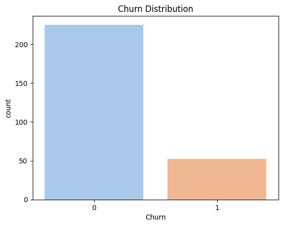

```python
#Number of users that churned vs those that did not churn
df_spark_churn.select(['userId', 'Churn']).dropDuplicates().groupBy('Churn').count().show()
churn_plt = sns.barplot(df_spark_churn.select(['userId', 'Churn']).dropDuplicates().groupBy('Churn').count().toPandas(), x = 'Churn', y='count', palette='pastel')
churn_plt.set_title('Churn Distribution')
```

```python
#A new feature that indicates the type of operating system a user uses
df_spark_feat = df_spark_churn.withColumn('Operating_System', when(col('userAgent').contains('Windows'), 'Windows')
                   .when(col('userAgent').contains('Linux'), 'Linux')
                   .otherwise('Macintosh'))
```

```python
#what distinct values are in the auth column
df_spark_feat.select("auth").distinct().show()
```

```
+---------+
|     auth|
+---------+
|Cancelled|
|Logged In|
+---------+
```

```python
#what distinct values are in the level column
df_spark_feat.select("level").distinct().show()
```

```
+-----+
|level|
+-----+
| free|
| paid|
+-----+
```

```python
df_spark_feat.groupby("method").count().show()
```

```
+------+------+
|method| count|
+------+------+
|   PUT|257818|
|   GET| 20336|
+------+------+
```

```
+-----+-----+
|level|count|
+-----+-----+
| free|  195|
| paid|  165|
+-----+-----+
```

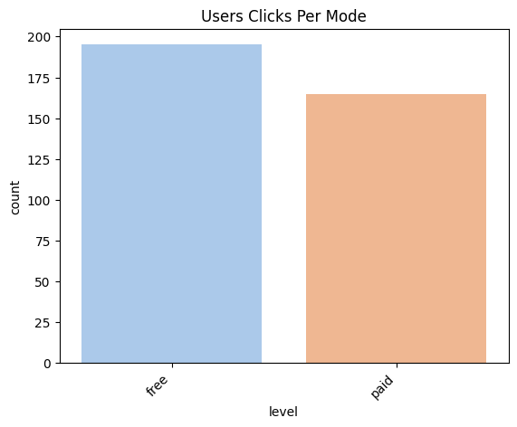

```python
#Most users are on free mode
df_spark_feat.select('userId','level').distinct().groupBy('level').count().show()
plot_lev = sns.barplot(df_spark_feat.select('userId','level').distinct().groupBy('level').count().toPandas(), \
                      x = 'level', y = 'count', palette='pastel')
plot_lev.set_xticklabels(plot_lev.get_xticklabels(), rotation=45, horizontalalignment='right')
plot_lev.set_title("Users Clicks Per Mode")
```

```python
#counts of the number of page clicks per page per level
df_spark_feat.groupby("level",'page').count().sort('level',desc('count')).show(100)
```

```
+-----+--------------------+------+
|level|                page| count|
+-----+--------------------+------+
| free|            NextSong| 41991|
| free|         Roll Advert|  3687|
| free|                Home|  2621|
| free|           Thumbs Up|  2209|
| free|     Add to Playlist|  1172|
| free|              Logout|   922|
| free|          Add Friend|   893|
| free|         Thumbs Down|   613|
| free|             Upgrade|   499|
| free|            Settings|   360|
| free|                Help|   322|
| free|      Submit Upgrade|   159|
| free|               About|    93|
| free|       Save Settings|    85|
| free|               Error|    53|
| free|Cancellation Conf...|    21|
| free|              Cancel|    21|
| paid|            NextSong|186117|
| paid|           Thumbs Up| 10342|
| paid|                Home|  7461|
| paid|     Add to Playlist|  5354|
| paid|          Add Friend|  3384|
| paid|              Logout|  2304|
| paid|           Downgrade|  2055|
| paid|         Thumbs Down|  1933|
| paid|            Settings|  1154|
| paid|                Help|  1132|
| paid|               About|   402|
| paid|         Roll Advert|   246|
| paid|       Save Settings|   225|
| paid|               Error|   199|
| paid|    Submit Downgrade|    63|
| paid|Cancellation Conf...|    31|
| paid|              Cancel|    31|
+-----+--------------------+------+
```

```
+-----+--------------------+-----+
|level|                page|count|
+-----+--------------------+-----+
| free|            NextSong|41991|
| free|         Roll Advert| 3687|
| free|                Home| 2621|
| free|           Thumbs Up| 2209|
| free|     Add to Playlist| 1172|
| free|              Logout|  922|
| free|          Add Friend|  893|
| free|         Thumbs Down|  613|
| free|             Upgrade|  499|
| free|            Settings|  360|
| free|                Help|  322|
| free|      Submit Upgrade|  159|
| free|               About|   93|
| free|       Save Settings|   85|
| free|               Error|   53|
| free|Cancellation Conf...|   21|
| free|              Cancel|   21|
+-----+--------------------+-----+
```

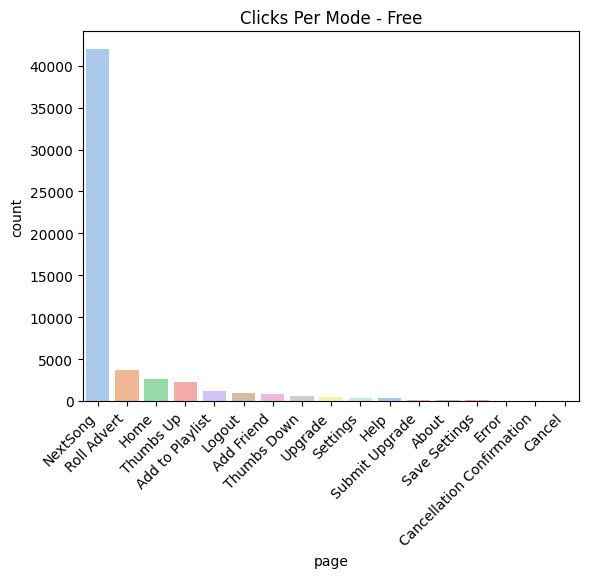

```python
#Free mode - clicks per users
df_spark_feat.groupby("level",'page').count().sort('level',desc('count')).filter(df_spark_feat['level'] == 'free').show()
plot1 = sns.barplot(df_spark_feat.groupby("level",'page').count().sort('level',desc('count')).filter(df_spark_feat['level'] == 'free').toPandas(), \
                      x = 'page', y = 'count', palette='pastel')
plot1.set_xticklabels(plot1.get_xticklabels(), rotation=45, horizontalalignment='right')
plot1.set_title("Clicks Per Mode - Free")
```

```
+-----+--------------------+------+
|level|                page| count|
+-----+--------------------+------+
| paid|            NextSong|186117|
| paid|           Thumbs Up| 10342|
| paid|                Home|  7461|
| paid|     Add to Playlist|  5354|
| paid|          Add Friend|  3384|
| paid|              Logout|  2304|
| paid|           Downgrade|  2055|
| paid|         Thumbs Down|  1933|
| paid|            Settings|  1154|
| paid|                Help|  1132|
| paid|               About|   402|
| paid|         Roll Advert|   246|
| paid|       Save Settings|   225|
| paid|               Error|   199|
| paid|    Submit Downgrade|    63|
| paid|Cancellation Conf...|    31|
| paid|              Cancel|    31|
+-----+--------------------+------+
```

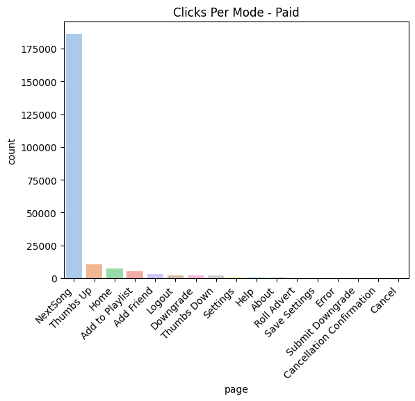

```python
#Paid mode - clicks per users
df_spark_feat.groupby("level",'page').count().sort('level',desc('count')).filter(df_spark_feat['level'] == 'paid').show()

plot2 = sns.barplot(df_spark_feat.groupby("level",'page').count().sort('level',desc('count')).filter(df_spark_feat['level'] == 'paid').toPandas(), \
                      x = 'page', y = 'count', palette='pastel')
plot2.set_xticklabels(plot2.get_xticklabels(), rotation=45, horizontalalignment='right')
plot2.set_title("Clicks Per Mode - Paid")
```

```python
df_spark_feat.toPandas().query('Churn==1').head()
```

|  | artist | auth | firstName | gender | itemInSession | lastName | length | level | location | method | page | registration | sessionId | song | status | ts | userAgent | userId | Churn | Operating_System |
| --- | --- | --- | --- | --- | --- | --- | --- | --- | --- | --- | --- | --- | --- | --- | --- | --- | --- | --- | --- | --- |
| 19592 | None | Cancelled | Adriel | M | 104 | Mendoza | NaN | paid | Kansas City, MO-KS | GET | Cancellation Confirmation | 1535623466000 | 514 | None | 200 | 1538943990000 | "Mozilla/5.0 (Macintosh; Intel Mac OS X 10_9_4... | 18 | 1 | Macintosh |
| 23072 | None | Cancelled | Diego | M | 56 | Mckee | NaN | paid | Phoenix-Mesa-Scottsdale, AZ | GET | Cancellation Confirmation | 1537167593000 | 540 | None | 200 | 1539033046000 | "Mozilla/5.0 (iPhone; CPU iPhone OS 7_1_2 like... | 32 | 1 | Macintosh |
| 36649 | None | Cancelled | Mason | M | 10 | Hart | NaN | free | Corpus Christi, TX | GET | Cancellation Confirmation | 1533157139000 | 174 | None | 200 | 1539318918000 | "Mozilla/5.0 (Macintosh; Intel Mac OS X 10_9_4... | 125 | 1 | Macintosh |
| 39109 | None | Cancelled | Alexander | M | 332 | Garcia | NaN | paid | Indianapolis-Carmel-Anderson, IN | GET | Cancellation Confirmation | 1536817381000 | 508 | None | 200 | 1539375441000 | Mozilla/5.0 (Windows NT 6.1; WOW64; rv:31.0) G... | 105 | 1 | Windows |
| 40728 | None | Cancelled | Kayla | F | 273 | Johnson | NaN | paid | Philadelphia-Camden-Wilmington, PA-NJ-DE-MD | GET | Cancellation Confirmation | 1538333829000 | 797 | None | 200 | 1539465584000 | Mozilla/5.0 (Windows NT 6.1; WOW64; rv:24.0) G... | 17 | 1 | Windows |

EDA

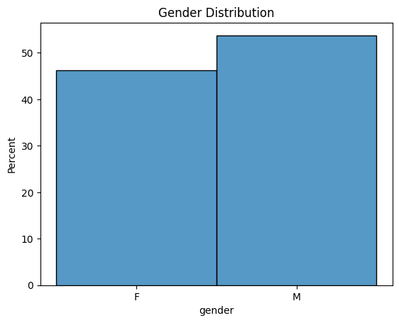

```python
#Percentage of users' gender
gender_plt = sns.histplot(data=df_spark_feat.select('userId','gender').distinct().toPandas(), x = 'gender', stat='percent', palette='pastel')
gender_plt.set_title('Gender Distribution')
```

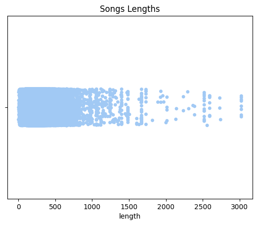

```python
#Lengths of the songs in the dataset
length_plt = sns.stripplot(df_spark_feat.toPandas(), x = 'length', palette='pastel')
length_plt.set_title('Songs Lengths')
```

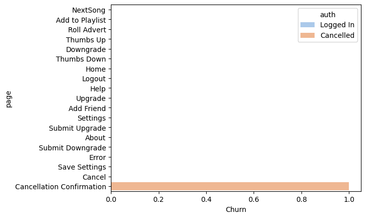

```python
#Check if the Churn is correctly assigned for the Cancellation Confirmation
sns.barplot(df_spark_churn.toPandas(), x = 'Churn', y= 'page', legend=True, hue='auth', palette='pastel')
```

# Feature Engineering

Once you've familiarized yourself with the data, build out the features you find promising to train your model on. To work with the full dataset, you can follow the following steps.

- Write a script to extract the necessary features from the smaller subset of data
- Ensure that your script is scalable, using the best practices discussed in Lesson 3
- Try your script on the full data set, debugging your script if necessary

If you are working in the classroom workspace, you can just extract features based on the small subset of data contained here. Be sure to transfer over this work to the larger dataset when you work on your Spark cluster.

```python
#first 5 rows of the data
df_spark_feat.show(2)
```

```
+----------------+---------+---------+------+-------------+--------+---------+-----+--------------------+------+--------+-------------+---------+---------+------+-------------+--------------------+------+-----+----------------+
|          artist|     auth|firstName|gender|itemInSession|lastName|   length|level|            location|method|    page| registration|sessionId|     song|status|           ts|           userAgent|userId|Churn|Operating_System|
+----------------+---------+---------+------+-------------+--------+---------+-----+--------------------+------+--------+-------------+---------+---------+------+-------------+--------------------+------+-----+----------------+
|  Martha Tilston|Logged In|    Colin|     M|           50| Freeman|277.89016| paid|     Bakersfield, CA|   PUT|NextSong|1538173362000|       29|Rockpools|   200|1538352117000|Mozilla/5.0 (Wind...|    30|    0|         Windows|
|Five Iron Frenzy|Logged In|    Micah|     M|           79|    Long|236.09424| free|Boston-Cambridge-...|   PUT|NextSong|1538331630000|        8|   Canada|   200|1538352180000|"Mozilla/5.0 (Win...|     9|    0|         Windows|
+----------------+---------+---------+------+-------------+--------+---------+-----+--------------------+------+--------+-------------+---------+---------+------+-------------+--------------------+------+-----+----------------+
only showing top 2 rows
```

```python
#distinct locations
df_spark_feat.select('location').distinct().show(10, False)
```

```
+--------------------------------------+
|location                              |
+--------------------------------------+
|Gainesville, FL                       |
|Atlantic City-Hammonton, NJ           |
|Deltona-Daytona Beach-Ormond Beach, FL|
|Kingsport-Bristol-Bristol, TN-VA      |
|New Haven-Milford, CT                 |
|Dubuque, IA                           |
|Las Vegas-Henderson-Paradise, NV      |
|Indianapolis-Carmel-Anderson, IN      |
|Seattle-Tacoma-Bellevue, WA           |
|Winston-Salem, NC                     |
+--------------------------------------+
only showing top 10 rows
```

```python
#User per location
df_spark_feat.groupby('location').count().sort(desc('count')).show(10, False)
```

```
+-------------------------------------------+-----+
|location                                   |count|
+-------------------------------------------+-----+
|Los Angeles-Long Beach-Anaheim, CA         |30131|
|New York-Newark-Jersey City, NY-NJ-PA      |23684|
|Boston-Cambridge-Newton, MA-NH             |13873|
|Houston-The Woodlands-Sugar Land, TX       |9499 |
|Charlotte-Concord-Gastonia, NC-SC          |7780 |
|Dallas-Fort Worth-Arlington, TX            |7605 |
|Louisville/Jefferson County, KY-IN         |6880 |
|Philadelphia-Camden-Wilmington, PA-NJ-DE-MD|5890 |
|Chicago-Naperville-Elgin, IL-IN-WI         |5114 |
|St. Louis, MO-IL                           |4858 |
+-------------------------------------------+-----+
only showing top 10 rows
```

```python
#Create a column with the state the user is in
df_spark_feat = df_spark_feat.withColumn('State', split(df_spark_churn['location'], "," )[1])
```

```python
df_spark_feat.show(5)
```

```
+----------------+---------+---------+------+-------------+--------+---------+-----+--------------------+------+--------+-------------+---------+--------------------+------+-------------+--------------------+------+-----+----------------+------+
|          artist|     auth|firstName|gender|itemInSession|lastName|   length|level|            location|method|    page| registration|sessionId|                song|status|           ts|           userAgent|userId|Churn|Operating_System| State|
+----------------+---------+---------+------+-------------+--------+---------+-----+--------------------+------+--------+-------------+---------+--------------------+------+-------------+--------------------+------+-----+----------------+------+
|  Martha Tilston|Logged In|    Colin|     M|           50| Freeman|277.89016| paid|     Bakersfield, CA|   PUT|NextSong|1538173362000|       29|           Rockpools|   200|1538352117000|Mozilla/5.0 (Wind...|    30|    0|         Windows|    CA|
|Five Iron Frenzy|Logged In|    Micah|     M|           79|    Long|236.09424| free|Boston-Cambridge-...|   PUT|NextSong|1538331630000|        8|              Canada|   200|1538352180000|"Mozilla/5.0 (Win...|     9|    0|         Windows| MA-NH|
|    Adam Lambert|Logged In|    Colin|     M|           51| Freeman| 282.8273| paid|     Bakersfield, CA|   PUT|NextSong|1538173362000|       29|   Time For Miracles|   200|1538352394000|Mozilla/5.0 (Wind...|    30|    0|         Windows|    CA|
|          Enigma|Logged In|    Micah|     M|           80|    Long|262.71302| free|Boston-Cambridge-...|   PUT|NextSong|1538331630000|        8|Knocking On Forbi...|   200|1538352416000|"Mozilla/5.0 (Win...|     9|    0|         Windows| MA-NH|
|       Daft Punk|Logged In|    Colin|     M|           52| Freeman|223.60771| paid|     Bakersfield, CA|   PUT|NextSong|1538173362000|       29|Harder Better Fas...|   200|1538352676000|Mozilla/5.0 (Wind...|    30|    0|         Windows|    CA|
+----------------+---------+---------+------+-------------+--------+---------+-----+--------------------+------+--------+-------------+---------+--------------------+------+-------------+--------------------+------+-----+----------------+------+
only showing top 5 rows
```

```python
#top 10 states
df_spark_feat.groupby('State').count().sort(desc('count')).show(10)
```

```
+---------+-----+
|    State|count|
+---------+-----+
|       CA|46771|
| NY-NJ-PA|23684|
|       TX|23494|
|    MA-NH|13873|
|       FL|13190|
|       NC|10688|
|    NC-SC| 7780|
|       CO| 7493|
|       MI| 7216|
|       NJ| 7001|
+---------+-----+
only showing top 10 rows
```

```python
#the feature of states the users are in
df_users_states = df_spark_feat.select('userId','State').distinct()
df_users_states.show(10, False)
```

```
+------+------------+
|userId|State       |
+------+------------+
|111   | MI         |
|102   | NY-NJ-PA   |
|34    | FL         |
|146   | SC-NC      |
|85    | CA         |
|38    | PA         |
|114   | NV         |
|13    | PA-NJ-DE-MD|
|6     | TX         |
|127   | TX         |
+------+------------+
only showing top 10 rows
```

```python
#the browser and operating system combinations users use to access the system
df_spark_feat.select('userAgent').distinct().toPandas().head()
```

|  | userAgent |
| --- | --- |
| 0 | "Mozilla/5.0 (Windows NT 5.1) AppleWebKit/537.... |
| 1 | Mozilla/5.0 (X11; Ubuntu; Linux i686; rv:31.0)... |
| 2 | "Mozilla/5.0 (Macintosh; Intel Mac OS X 10_9_4... |
| 3 | Mozilla/5.0 (Windows NT 6.1; WOW64; rv:30.0) G... |
| 4 | Mozilla/5.0 (Windows NT 6.3; WOW64; rv:31.0) G... |

```python
#Extract the operating system as a column
df_spark_feat = df_spark_feat.withColumn('Operating_System', when(col('userAgent').contains('Windows'), 'Windows')
                   .when(col('userAgent').contains('Linux'), 'Linux')
                   .otherwise('Macintosh'))
```

```python
#The distribution of operating system used by users
df_spark_feat.select('userId','Operating_System','churn').dropDuplicates().groupBy('Operating_System','Churn').count().show()
```

```
+----------------+-----+-----+
|Operating_System|Churn|count|
+----------------+-----+-----+
|       Macintosh|    0|  102|
|       Macintosh|    1|   23|
|         Windows|    0|  111|
|           Linux|    1|    5|
|           Linux|    0|   12|
|         Windows|    1|   24|
+----------------+-----+-----+
```

```python
df_users_OS = df_spark_feat.select('userId','Operating_System').distinct()
df_users_OS.show()
```

```
+------+----------------+
|userId|Operating_System|
+------+----------------+
|   114|         Windows|
|   138|       Macintosh|
|   101|         Windows|
|    97|         Windows|
|     5|         Windows|
|   124|       Macintosh|
|   120|       Macintosh|
|   137|       Macintosh|
|    66|         Windows|
|   118|         Windows|
|   100|         Windows|
|    34|       Macintosh|
|    10|       Macintosh|
|    40|         Windows|
|    39|         Windows|
|    75|         Windows|
|     3|         Windows|
|   145|           Linux|
|    83|           Linux|
|    88|         Windows|
+------+----------------+
only showing top 20 rows
```

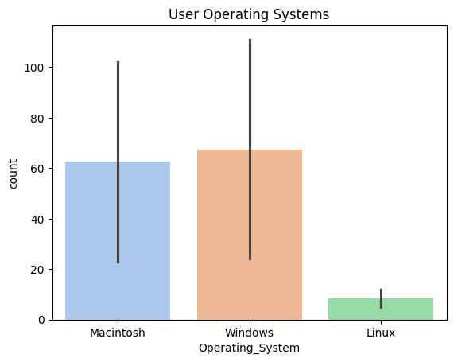

```python
#most users in the dataset use windows and least use Linux
df_os_plt = df_spark_feat.select('userId','Operating_System','Churn').dropDuplicates().groupBy('Operating_System','Churn').count()
os_plot = sns.barplot(data=df_os_plt.toPandas(), x = 'Operating_System', y='count', palette='pastel' )
os_plot.set_title('User Operating Systems')
```

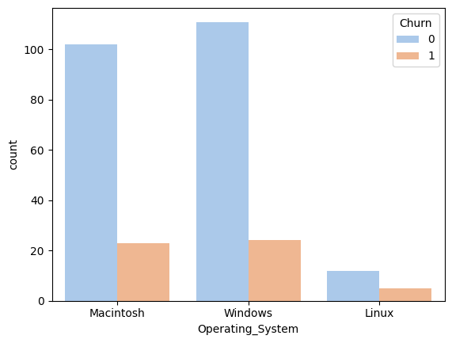

```python
#Comparison of operating system use and the amount of churn per operating system
sns.barplot(data=df_os_plt.toPandas(), x = 'Operating_System', y='count', hue='Churn', palette='pastel')
```

```python
#colun feature of the time from registration to the timestamp of the record
df_spark_feat = df_spark_feat.withColumn('reg_to_ts_time', df_spark_feat['ts'] - df_spark_feat['registration'])
```

```python
#feature of time since registration
df_spark_feat = df_spark_feat.withColumn('days_since_reg',(df_spark_feat['reg_to_ts_time']/1000/3600/24))
```

```python
df_spark_feat.show(5)
```

```
+----------------+---------+---------+------+-------------+--------+---------+-----+--------------------+------+--------+-------------+---------+--------------------+------+-------------+--------------------+------+-----+----------------+------+--------------+------------------+
|          artist|     auth|firstName|gender|itemInSession|lastName|   length|level|            location|method|    page| registration|sessionId|                song|status|           ts|           userAgent|userId|Churn|Operating_System| State|reg_to_ts_time|    days_since_reg|
+----------------+---------+---------+------+-------------+--------+---------+-----+--------------------+------+--------+-------------+---------+--------------------+------+-------------+--------------------+------+-----+----------------+------+--------------+------------------+
|  Martha Tilston|Logged In|    Colin|     M|           50| Freeman|277.89016| paid|     Bakersfield, CA|   PUT|NextSong|1538173362000|       29|           Rockpools|   200|1538352117000|Mozilla/5.0 (Wind...|    30|    0|         Windows|    CA|     178755000|2.0689236111111113|
|Five Iron Frenzy|Logged In|    Micah|     M|           79|    Long|236.09424| free|Boston-Cambridge-...|   PUT|NextSong|1538331630000|        8|              Canada|   200|1538352180000|"Mozilla/5.0 (Win...|     9|    0|         Windows| MA-NH|      20550000|0.2378472222222222|
|    Adam Lambert|Logged In|    Colin|     M|           51| Freeman| 282.8273| paid|     Bakersfield, CA|   PUT|NextSong|1538173362000|       29|   Time For Miracles|   200|1538352394000|Mozilla/5.0 (Wind...|    30|    0|         Windows|    CA|     179032000|2.0721296296296297|
|          Enigma|Logged In|    Micah|     M|           80|    Long|262.71302| free|Boston-Cambridge-...|   PUT|NextSong|1538331630000|        8|Knocking On Forbi...|   200|1538352416000|"Mozilla/5.0 (Win...|     9|    0|         Windows| MA-NH|      20786000|0.2405787037037037|
|       Daft Punk|Logged In|    Colin|     M|           52| Freeman|223.60771| paid|     Bakersfield, CA|   PUT|NextSong|1538173362000|       29|Harder Better Fas...|   200|1538352676000|Mozilla/5.0 (Wind...|    30|    0|         Windows|    CA|     179314000|2.0753935185185184|
+----------------+---------+---------+------+-------------+--------+---------+-----+--------------------+------+--------+-------------+---------+--------------------+------+-------------+--------------------+------+-----+----------------+------+--------------+------------------+
only showing top 5 rows
```

```python
df_users_time_since_reg = df_spark_feat.groupby('userId').max('days_since_reg').drop_duplicates()
```

```python
#unique users
df_users = df_spark_feat.select('userId').distinct()
```

```python
df_users.show(5)
```

```
+------+
|userId|
+------+
|    51|
|   124|
|     7|
|    54|
|    15|
+------+
only showing top 5 rows
```

```python
df_users.count()
```

```
225
```

```python
#Create a dataframe with the records where users churned
df_users_churned = df_spark_feat.filter(df_spark_churn['Churn']==1).select('userId','Churn').drop_duplicates()
```

```python
df_users_churned.count()
```

```
52
```

```python
#dataframe of the sum of the lenghts of songs listened to by the users
df_users_lengths = df_spark_feat.groupby('userId').sum('length').drop_duplicates()
```

```python
df_users_lengths.show(5)
```

```
+------+------------------+
|userId|       sum(length)|
+------+------------------+
|    51| 523275.8428000001|
|   124|1012312.0927899999|
|     7|        38034.0871|
|    54| 711344.9195399999|
|    15|477307.60580999975|
+------+------------------+
only showing top 5 rows
```

```python
df_users_lengths.count()
```

```
225
```

```python
#dataframes of earliest registration and latest timestamp of the users
df_users_reg = df_spark_feat.groupby('userId').min('registration').drop_duplicates()
df_users_ts = df_spark_feat.groupby('userId').max('ts').drop_duplicates()
```

```python
df_users_ts.show(2)
```

```
+------+-------------+
|userId|      max(ts)|
+------+-------------+
|    51|1539761972000|
|   124|1543590766000|
+------+-------------+
only showing top 2 rows
```

```python
#number of times a user clicked on thumbs down
df_users_thumbs_down = df_spark_feat.filter(df_spark_churn['page'] == 'Thumbs Down'). \
                                groupby('userId').count().withColumnRenamed("count", "thumbs_down").drop_duplicates()
```

```python
df_users_thumbs_down.show(10)
```

```
+------+-----------+
|userId|thumbs_down|
+------+-----------+
|    51|         21|
|   124|         41|
|     7|          1|
|    15|         14|
|    54|         29|
|   132|         17|
|   101|         16|
|    11|          9|
|    29|         22|
|    69|          9|
+------+-----------+
only showing top 10 rows
```

```python
#number of times there was an error for the user
df_users_errors = df_spark_feat.filter(df_spark_churn['page'] == 'Error').groupby('userId').count().withColumnRenamed("count", "errors").drop_duplicates()
```

```python
df_users_errors.show(10)
```

```
+------+------+
|userId|errors|
+------+------+
|   124|     6|
|    51|     1|
|    15|     2|
|    54|     1|
|   101|     3|
|    42|     7|
|    73|     1|
|    30|     1|
|    28|     1|
|    98|     3|
+------+------+
only showing top 10 rows
```

```python
df_gender = df_spark_feat.select('userId','gender').distinct()
df_gender.count()
```

```
225
```

```python
df_users.count(), df_users_churned.count()
```

```
(225, 52)
```

```python
#create a model ready dataframe by joining the dfs created
df_model = df_users.join(df_users_lengths,['userId'], 'left').withColumnRenamed("sum(length)", "tot_length_songs") \
            .join(df_users_reg, ['userId'], 'left').withColumnRenamed("min(registration)", "first_reg") \
            .join(df_users_ts, ['userId'], 'left').withColumnRenamed("max(ts)", "last_timestamp") \
            .join(df_users_errors, ['userId'], 'left') \
            .join(df_users_thumbs_down, ['userId'], 'left') \
            .join(df_users_states, ['userId'], 'left') \
            .join(df_users_OS, ['userId'], 'left') \
            .join(df_gender, ['userId'], 'left') \
            .join(df_users_churned, ['userId'], 'left').fillna(0, subset='Churn')
```

```python
df_model = df_model.withColumn('days_since_reg',((df_model['last_timestamp'] - df_model['first_reg'])/1000/3600/24))
```

```python
#Check for null/missing values values
df_model.select([count(when(col(i).isNull(), i)).alias(i) for i in df_model.columns]).show()
```

```
+------+----------------+---------+--------------+------+-----------+-----+----------------+------+-----+--------------+
|userId|tot_length_songs|first_reg|last_timestamp|errors|thumbs_down|State|Operating_System|gender|Churn|days_since_reg|
+------+----------------+---------+--------------+------+-----------+-----+----------------+------+-----+--------------+
|     0|               0|        0|             0|   108|         22|    0|               0|     0|    0|             0|
+------+----------------+---------+--------------+------+-----------+-----+----------------+------+-----+--------------+
```

```python
df_model.count()
```

```
225
```

```python
df_model = df_model.fillna(0, subset=['errors','thumbs_down'])
```

```python
#Check for null/missing values values
df_model.select([count(when(col(i).isNull(), i)).alias(i) for i in df_model.columns]).show()
```

```
+------+----------------+---------+--------------+------+-----------+-----+----------------+------+-----+--------------+
|userId|tot_length_songs|first_reg|last_timestamp|errors|thumbs_down|State|Operating_System|gender|Churn|days_since_reg|
+------+----------------+---------+--------------+------+-----------+-----+----------------+------+-----+--------------+
|     0|               0|        0|             0|     0|          0|    0|               0|     0|    0|             0|
+------+----------------+---------+--------------+------+-----------+-----+----------------+------+-----+--------------+
```

```python
df_model.groupby('Churn').count().show()
```

```
+-----+-----+
|Churn|count|
+-----+-----+
|    1|   52|
|    0|  173|
+-----+-----+
```

# Modeling

Split the full dataset into train, test, and validation sets. Test out several of the machine learning methods you learned. Evaluate the accuracy of the various models, tuning parameters as necessary. Determine your winning model based on test accuracy and report results on the validation set. Since the churned users are a fairly small subset, I suggest using F1 score as the metric to optimize.

# Model Preparation

```python
#remove the userId column from the dataframe that will be ran into the models
df_model = df_model.drop('userId')
```

```python
#The schema of the dataframe to model
df_model.printSchema()
```

```
root
 |-- tot_length_songs: double (nullable = true)
 |-- first_reg: long (nullable = true)
 |-- last_timestamp: long (nullable = true)
 |-- errors: long (nullable = true)
 |-- thumbs_down: long (nullable = true)
 |-- State: string (nullable = true)
 |-- Operating_System: string (nullable = true)
 |-- gender: string (nullable = true)
 |-- Churn: integer (nullable = true)
 |-- days_since_reg: double (nullable = true)
```

```python
col_list = ['State','Operating_System','gender']
```

```python
#Stringidexing, convering the string features to numericals
def indexer_cols(col_list, df):
    for i in col_list:
        indexer = StringIndexer(inputCol=i, outputCol = i+'_indexed')#, handleInvalid='keep')
        df = indexer.fit(df).transform(df)

    return df

df_model = indexer_cols(col_list, df_model)
```

```python
df_model.printSchema()
```

```
root
 |-- tot_length_songs: double (nullable = true)
 |-- first_reg: long (nullable = true)
 |-- last_timestamp: long (nullable = true)
 |-- errors: long (nullable = true)
 |-- thumbs_down: long (nullable = true)
 |-- State: string (nullable = true)
 |-- Operating_System: string (nullable = true)
 |-- gender: string (nullable = true)
 |-- Churn: integer (nullable = true)
 |-- days_since_reg: double (nullable = true)
 |-- State_indexed: double (nullable = false)
 |-- Operating_System_indexed: double (nullable = false)
 |-- gender_indexed: double (nullable = false)
```

```python
assembler = VectorAssembler(inputCols = ['tot_length_songs','first_reg','last_timestamp','errors','gender_indexed',
                                        'thumbs_down','State_indexed',
                                        'Operating_System_indexed'], outputCol='features')#, handleInvalid='keep')
```

```python
scaler = Normalizer(inputCol='features', outputCol = 'scaled_features')
```

```python
#Check for null/missing values values
df_model.select([count(when(col(i).isNull(), i)).alias(i) for i in df_model.columns]).show()
```

```
+----------------+---------+--------------+------+-----------+-----+----------------+------+-----+--------------+-------------+------------------------+--------------+
|tot_length_songs|first_reg|last_timestamp|errors|thumbs_down|State|Operating_System|gender|Churn|days_since_reg|State_indexed|Operating_System_indexed|gender_indexed|
+----------------+---------+--------------+------+-----------+-----+----------------+------+-----+--------------+-------------+------------------------+--------------+
|               0|        0|             0|     0|          0|    0|               0|     0|    0|             0|            0|                       0|             0|
+----------------+---------+--------------+------+-----------+-----+----------------+------+-----+--------------+-------------+------------------------+--------------+
```

```python
df_model.printSchema()
```

```
root
 |-- tot_length_songs: double (nullable = true)
 |-- first_reg: long (nullable = true)
 |-- last_timestamp: long (nullable = true)
 |-- errors: long (nullable = true)
 |-- thumbs_down: long (nullable = true)
 |-- State: string (nullable = true)
 |-- Operating_System: string (nullable = true)
 |-- gender: string (nullable = true)
 |-- Churn: integer (nullable = true)
 |-- days_since_reg: double (nullable = true)
 |-- State_indexed: double (nullable = false)
 |-- Operating_System_indexed: double (nullable = false)
 |-- gender_indexed: double (nullable = false)
```

```python
#split the data into the train and test datasets for training and tesing the models
train_data, test_data = df_model.randomSplit([0.7, 0.3])
```

# Logistic Regression

```python
#Train and test the logistic regression model
lr = LogisticRegression(featuresCol='scaled_features', labelCol='Churn')
pipeline_lr = Pipeline(stages=[assembler, scaler, lr])
model_lr = pipeline_lr.fit(train_data)
results_lr = model_lr.transform(test_data)
```

```python
#Evaluate the model's performance
evaluator = MulticlassClassificationEvaluator(predictionCol="prediction", labelCol="Churn")

f1_lr = evaluator.evaluate(results_lr, {evaluator.metricName: "f1"})
precision_lr = evaluator.evaluate(results_lr, {evaluator.metricName: "weightedPrecision"})
recall_lr = evaluator.evaluate(results_lr, {evaluator.metricName: "weightedRecall"})
accuracy_lr = evaluator.evaluate(results_lr, {evaluator.metricName: "accuracy"})

print(f"Accuracy: {accuracy_lr}")
print(f"Precision: {precision_lr}")
print(f"Recall: {recall_lr}")
print(f"F1 Score: {f1_lr}")
```

```
Accuracy: 0.7758620689655172
Precision: 0.7880194518125554
Recall: 0.7758620689655173
F1 Score: 0.7355193371056408
```

# Randon Forest Classifier

```python
#Train and test the logistic regression model
rfc = RandomForestClassifier(featuresCol="scaled_features", labelCol="Churn")
pieline_rfc = Pipeline(stages=[assembler,scaler,rfc])
model_rfc = pieline_rfc.fit(train_data)
results_rfc = model_rfc.transform(test_data)
```

```python
evaluator = MulticlassClassificationEvaluator(predictionCol="prediction", labelCol="Churn")

f1_rfc = evaluator.evaluate(results_rfc, {evaluator.metricName: "f1"})
precision_rfc = evaluator.evaluate(results_rfc, {evaluator.metricName: "weightedPrecision"})
recall_rfc = evaluator.evaluate(results_rfc, {evaluator.metricName: "weightedRecall"})
accuracy_rfc = evaluator.evaluate(results_rfc, {evaluator.metricName: "accuracy"})

print(f"Accuracy: {accuracy_rfc}")
print(f"Precision: {precision_rfc}")
print(f"Recall: {recall_rfc}")
print(f"F1 Score: {f1_rfc}")
```

```
Accuracy: 0.8448275862068966
Precision: 0.8435782108945526
Recall: 0.8448275862068966
F1 Score: 0.8359096313912009
```

# Gradient Boosted Tree Classifier

```python
#Train and test the logistic regression model
gbt = GBTClassifier(featuresCol='scaled_features', labelCol='Churn')
pipeline_gbt = Pipeline(stages=[assembler,scaler,gbt])
model_gbt = pipeline_gbt.fit(train_data)
results_gbt = model_gbt.transform(test_data)
```

```python
evaluator = MulticlassClassificationEvaluator(predictionCol="prediction", labelCol="Churn")

f1_gbt = evaluator.evaluate(results_gbt, {evaluator.metricName: "f1"})
precision_gbt = evaluator.evaluate(results_gbt, {evaluator.metricName: "weightedPrecision"})
recall_gbt = evaluator.evaluate(results_gbt, {evaluator.metricName: "weightedRecall"})
accuracy_gbt = evaluator.evaluate(results_gbt, {evaluator.metricName: "accuracy"})

print(f"Accuracy: {accuracy_gbt}")
print(f"Precision: {precision_gbt}")
print(f"Recall: {recall_gbt}")
print(f"F1 Score: {f1_gbt}")
```

```
Accuracy: 0.8620689655172413
Precision: 0.8606542882404951
Recall: 0.8620689655172413
F1 Score: 0.8560812616947341
```

```python
#df to store the scores
scores_f1 = pd.DataFrame(columns =['Model', "F1 Score"])
```

```python
#Adding models' score onto the df
scores_f1.loc[-1] = ['GBTClassifier', f1_gbt]
scores_f1.index = scores_f1.index + 1
scores_f1 = scores_f1.sort_index()
```

```python
scores_f1.loc[-1] = ['RandomForestClassifier', f1_rfc]  # Adding a row
scores_f1.index = scores_f1.index + 1  # Shifting index
scores_f1 = scores_f1.sort_index()     # Sorting by index
```

```python
scores_f1.loc[-1] = ['LogisticRegression', f1_lr]  # Adding a row
scores_f1.index = scores_f1.index + 1  # Shifting index
scores_f1 = scores_f1.sort_index()     # Sorting by index
```

```python
scores_f1.sort_values(by='F1 Score', inplace=True, ascending=False)
scores_f1.head()
```

|  | Model | F1 Score |
| --- | --- | --- |
| 2 | GBTClassifier | 0.856081 |
| 1 | RandomForestClassifier | 0.835910 |
| 0 | LogisticRegression | 0.735519 |

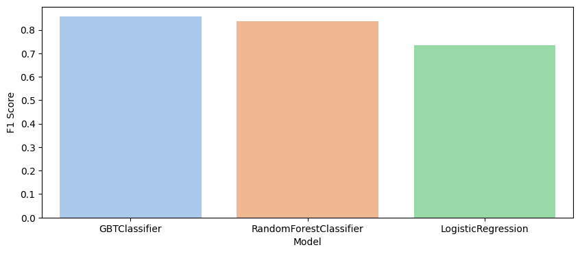

```python
plt.figure(figsize=(10,4))
sns.barplot(data=scores_f1, x='Model', y='F1 Score' , palette='pastel')
```

# Hyperparameter tuning

```python
#paramGrid_lr = ParamGridBuilder().addGrid(lr.regParam, [0.01, 0.1, 0.5, 1.0, 2.0]).build()
gb_paramGrid = ParamGridBuilder().addGrid(gbt.maxDepth, [2, 5, 10]).build()
```

```python
evaluator = MulticlassClassificationEvaluator(labelCol="Churn", predictionCol="prediction", metricName="f1")
```

```python
cv = CrossValidator(estimator=pipeline_gbt, estimatorParamMaps=gb_paramGrid, evaluator=evaluator, numFolds=3)
```

```python
train_data2 = train_data.withColumn("Churn", col("Churn").cast("double"))
```

```python
model_cv = cv.fit(train_data2)
```

```python
results_cv = model_cv.transform(test_data)
```

```python
f1_cv = evaluator.evaluate(results_cv, {evaluator.metricName: "f1"})

print(f"F1 Score: {f1_cv}")
```

```
F1 Score: 0.8400575803180004
```

```python
scores_f1.loc[-1] = ['GBTClassifier - Tuned', f1_cv]
scores_f1.index = scores_f1.index + 1
scores_f1 = scores_f1.sort_index()
```

```python
scores_f1.sort_values(by='F1 Score', inplace=True, ascending=False)
scores_f1.head()
```

|  | Model | F1 Score |
| --- | --- | --- |
| 3 | GBTClassifier | 0.856081 |
| 0 | GBTClassifier - Tuned | 0.840058 |
| 2 | RandomForestClassifier | 0.835910 |
| 1 | LogisticRegression | 0.735519 |

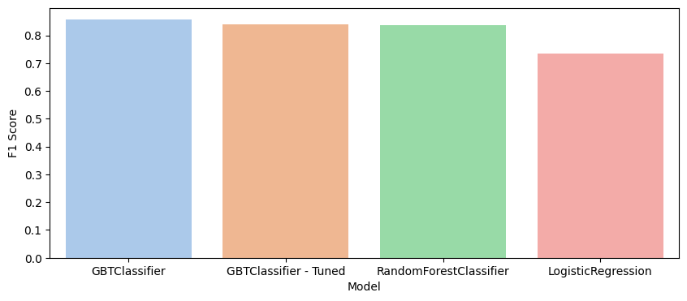

```python
plt.figure(figsize=(10,4))
sns.barplot(data=scores_f1, x='Model', y='F1 Score', palette='pastel' )
```

# Final Steps

Clean up your code, adding comments and renaming variables to make the code easier to read and maintain. Refer to the Spark Project Overview page and Data Scientist Capstone Project Rubric to make sure you are including all components of the capstone project and meet all expectations. Remember, this includes thorough documentation in a README file in a Github repository, as well as a web app or blog post.